# 빅데이터시각화_09장

Lee Jun Haeng

2021 11 23

# 9. R 그래픽 색상 다루기

### 09.1 R 색상 기초

#### 09.1_1 colors() 함수

```r
colors()[1:20]
```

```
##  [1] "white"         "aliceblue"     "antiquewhite"  "antiquewhite1"
##  [5] "antiquewhite2" "antiquewhite3" "antiquewhite4" "aquamarine"
##  [9] "aquamarine1"   "aquamarine2"   "aquamarine3"   "aquamarine4"
## [13] "azure"         "azure1"        "azure2"        "azure3"
## [17] "azure4"        "beige"         "bisque"        "bisque1"
```

#### 09.1_2 RGB 색상 코드

```r
col2rgb("red")
```

```
##       [,1]
## red    255
## green    0
## blue     0
```

```r
col2rgb(colors()[1:8])
```

```
##       [,1] [,2] [,3] [,4] [,5] [,6] [,7] [,8]
## red    255  240  250  255  238  205  139  127
## green  255  248  235  239  223  192  131  255
## blue   255  255  215  219  204  176  120  212
```

```r
rainbow(7)
```

```
## [1] "#FF0000" "#FFDB00" "#49FF00" "#00FF92" "#0092FF" "#4900FF" "#FF00DB"
```

##### 예제1

16진법 코드로 색상을 지정하고, 불투명도에 따라 그림이 달라지는 것을 보여준다.

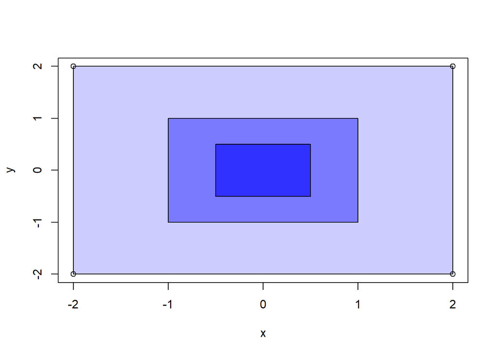

```r
x <- c(-2, 2, 2, -2)
y <- c(-2, -2, 2, 2)
plot(x, y)
polygon(x, y, col="#0000FF33")   # "#0000FF"는 "blue"에 해당
x.1 <- c(-1, 1, 1, -1)
y.1 <- c(-1, -1, 1, 1)
polygon(x.1, y.1, col="#0000FF66")   # 불투명도(opacity)를 높임
x.2 <- c(-.5, .5, .5, -.5)
y.2 <- c(-.5, -.5, .5, .5)
polygon(x.2, y.2, col="#0000FF99")   # 불투명도를 더 높임
```

#### 09.1_3 HSV 색상 좌표

```r
hsv(1,1,1)
```

```
## [1] "#FF0000"
```

```r
hsv(1/3,1,1)
```

```
## [1] "#00FF00"
```

```r
hsv(2/3,1,1)
```

```
## [1] "#0000FF"
```

```r
rgb2hsv(col2rgb("blue"))
```

```
##        [,1]
## h 0.6666667
## s 1.0000000
## v 1.0000000
```

### 09.2 컬러 옵션(col=) 사용하기

#### 09.2_1 기본 컬러 옵션

```r
(a <- gray(seq(0, 1, len=20)))
```

```
##  [1] "#000000" "#0D0D0D" "#1B1B1B" "#282828" "#363636" "#434343" "#515151"
##  [8] "#5E5E5E" "#6B6B6B" "#797979" "#868686" "#949494" "#A1A1A1" "#AEAEAE"
## [15] "#BCBCBC" "#C9C9C9" "#D7D7D7" "#E4E4E4" "#F2F2F2" "#FFFFFF"
```

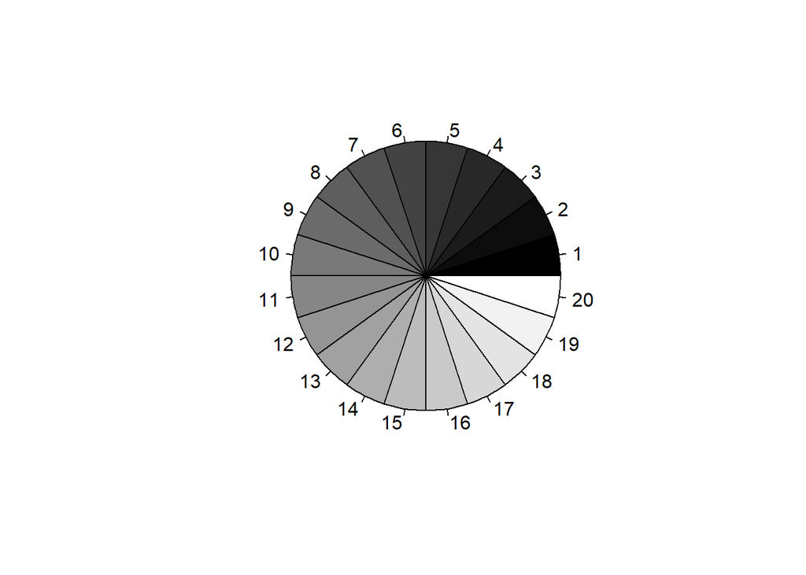

```r
# gray(level=seq(0, 1, len=20))과 동일하며, 0(black)~1(white) 사이의 20개 색상을 지정
pie(rep(1, 20), col=a)
```

```r
(b <- palette(gray(seq(0, 1, len=20))))
```

```
## [1] "black"   "#DF536B" "#61D04F" "#2297E6" "#28E2E5" "#CD0BBC" "#F5C710"
## [8] "gray62"
```

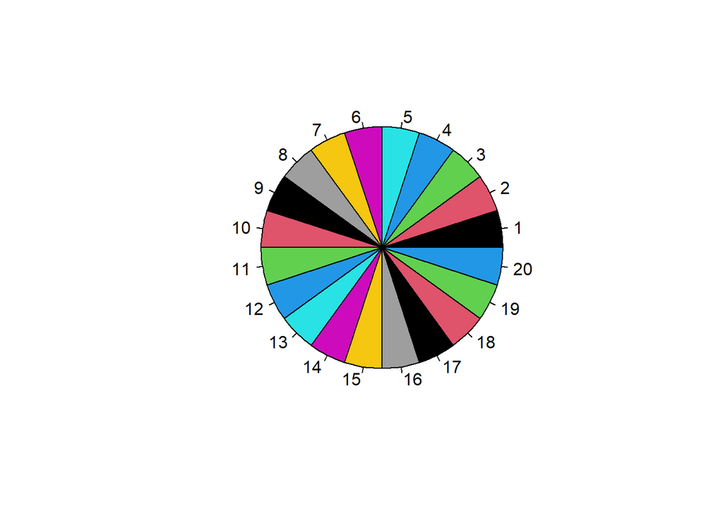

```r
pie(rep(1, 20), col=b)
```

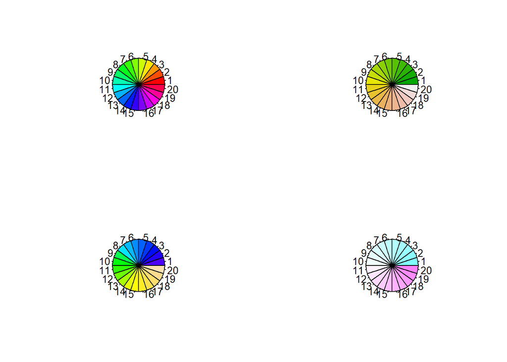

```r
par(mfrow=c(2,2))
pie(rep(1, 20), col=rainbow(20))  # 무지개 색 계열로 20개 색상을 지정함
pie(rep(1, 20), col=terrain.colors(20))  # terrain은 지형(지질) 관련 색상임
pie(rep(1, 20), col=topo.colors(20))  # topo는 지형 관련 색상임
pie(rep(1, 20), col=cm.colors(20))  # cm은 (cyan, magenta) 계열의 색상임
```

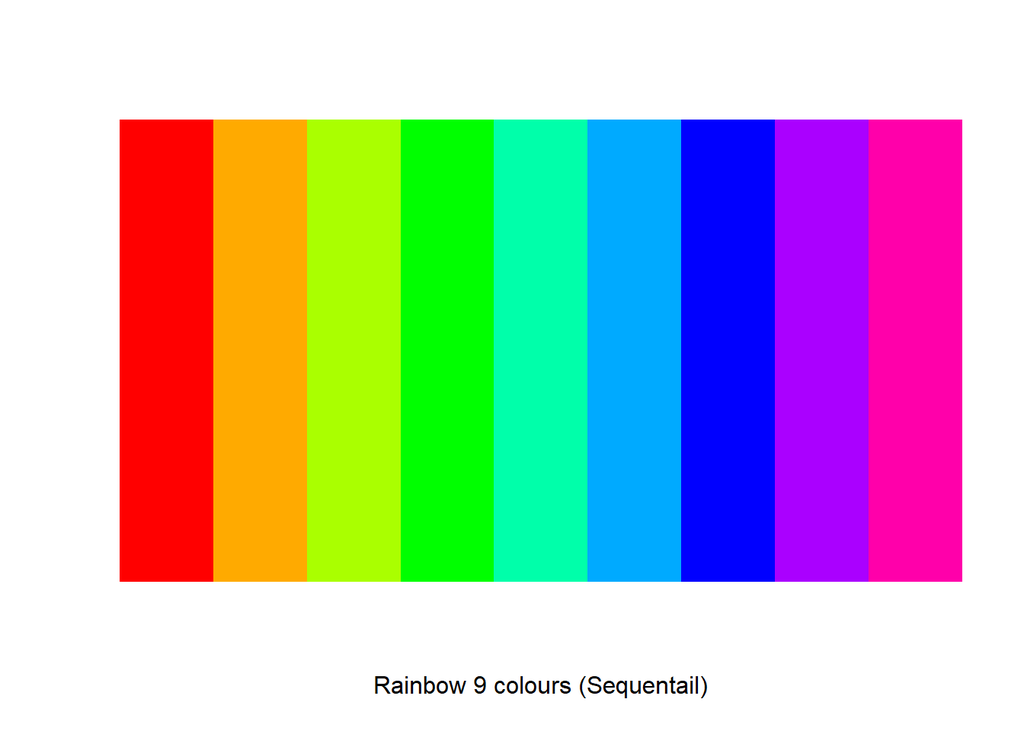

```r
image(1:9, 1, as.matrix(1:9), col=rainbow(9),
      xlab="Rainbow 9 colours (Sequentail)", ylab="",
      xaxt="n", yaxt="n", bty="n")
```

#### 09.2_2 pallette() 함수 이용하기

palette() 함수는 col= 옵션이 수치형 인덱스를 가질 때 사용되는 색상 palette를 보여주거나 조작(view or manipulate)한다(그래픽에서 par() 함수의 역할과 유사함).

```r
## palette() 함수 이용하기
palette("default")  # palette을 default palette로 지정
palette()  # 디폴트로 지정된 palette의 색상을 보여준다.
```

```
## [1] "black"   "#DF536B" "#61D04F" "#2297E6" "#28E2E5" "#CD0BBC" "#F5C710"
## [8] "gray62"
```

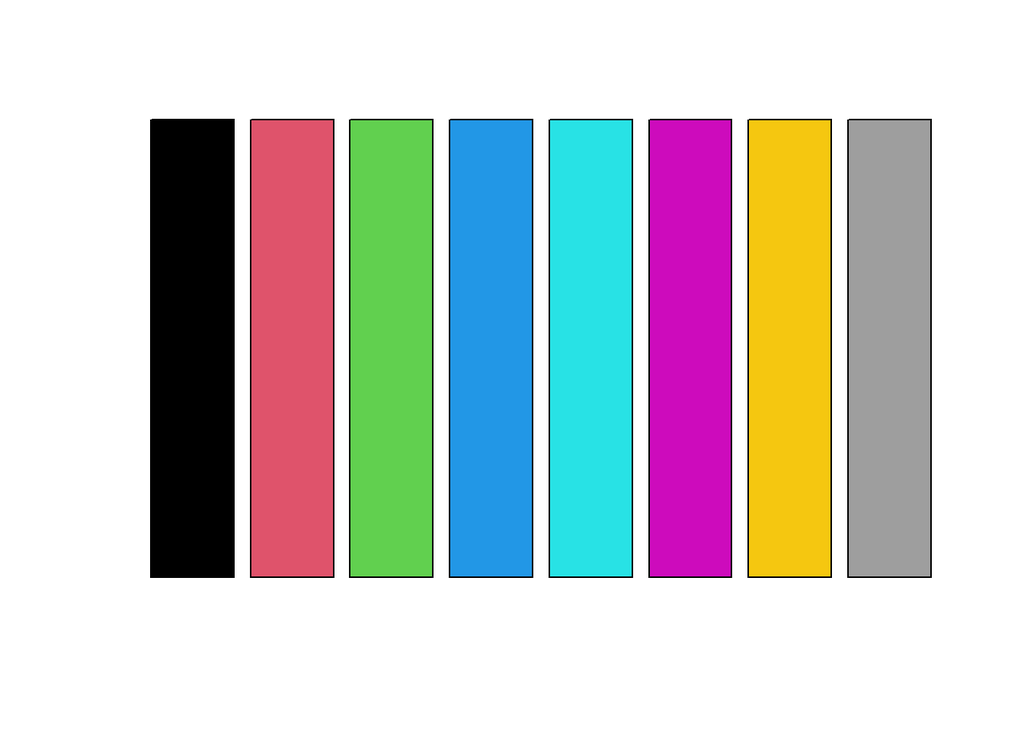

```r
barplot(rep(1, 8), yaxt="n", col=1:8)
```

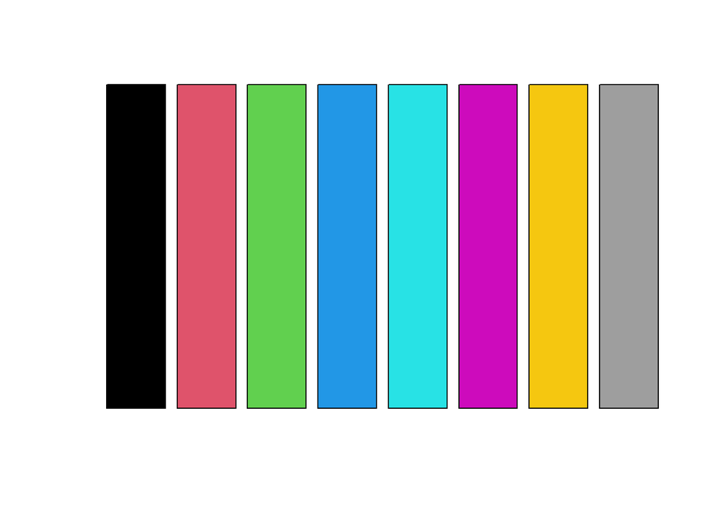

```r
barplot(rep(1, 8), yaxt="n", col=palette())
```

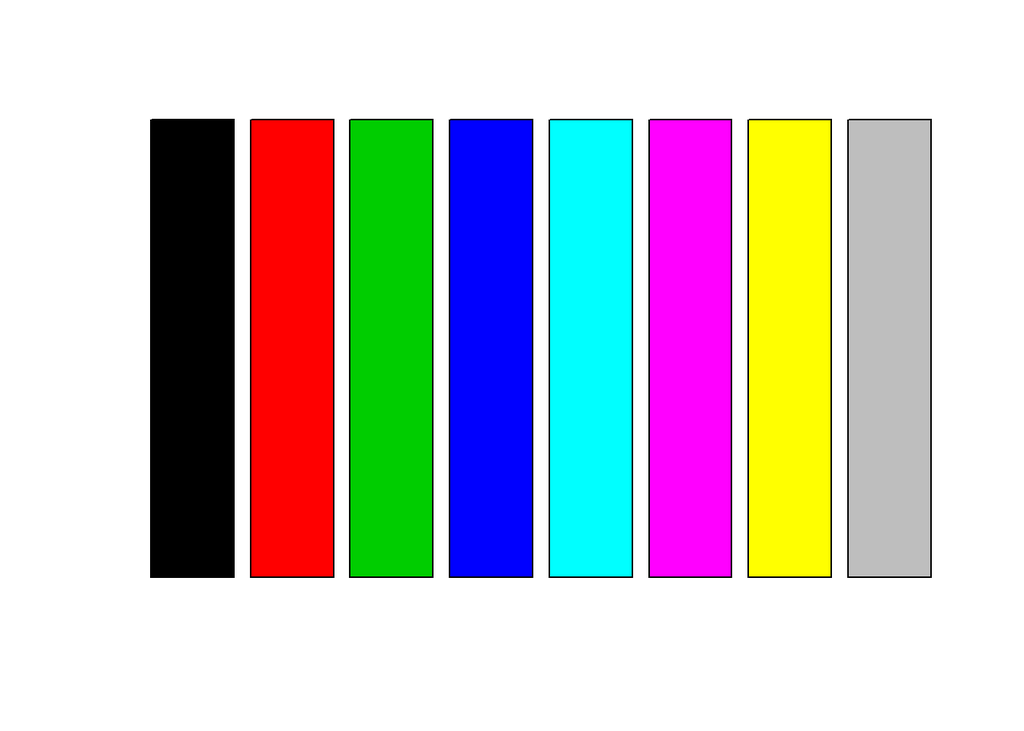

```r
## col=1과 같이 숫자를 지정하는 것은 col=palette()[1]과 같음
barplot(rep(1, 8), yaxt="n",
        col=c("black", "red", "green3", "blue",
              "cyan", "magenta", "yellow", "gray"))
```

palette를 다르게 지정하여 그림을 그리면 다음과 같다.

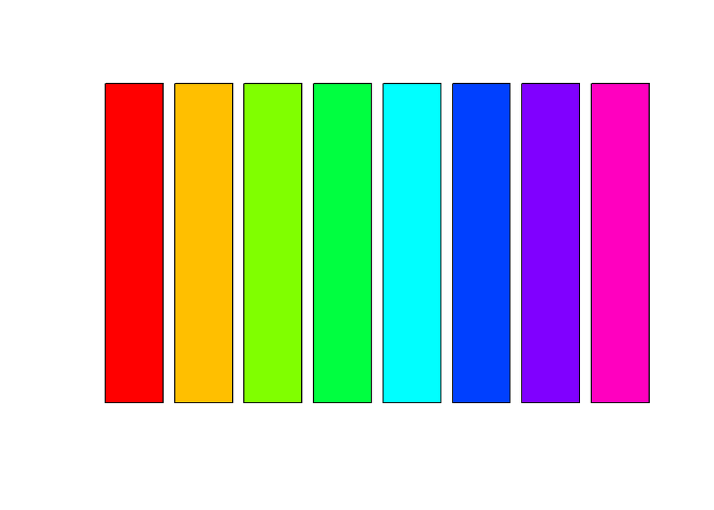

```r
palette(rainbow(8))  # rainbow 계열을 8개의 색으로 등분한 palette를 지정
barplot(rep(1, 8), yaxt="n", col=1:8)
```

```r
palette(gray(0:7 / 7))  # gray 계열을 8개의 색으로 등분한 palette를 지정
palette()
```

```
## [1] "black"   "gray14"  "#494949" "#6D6D6D" "#929292" "#B6B6B6" "gray86"
## [8] "white"
```

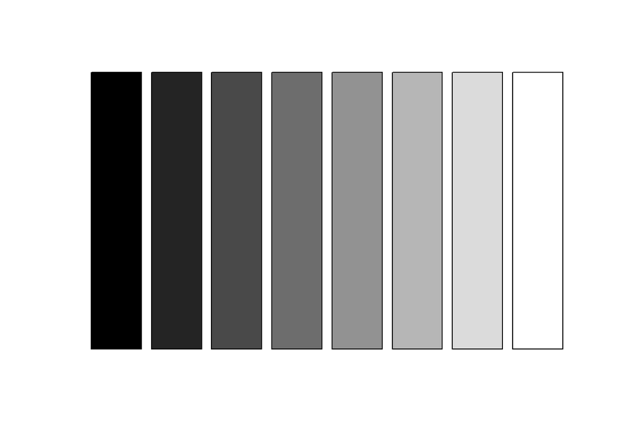

```r
barplot(rep(1, 8), yaxt="n", col=1:8)
```

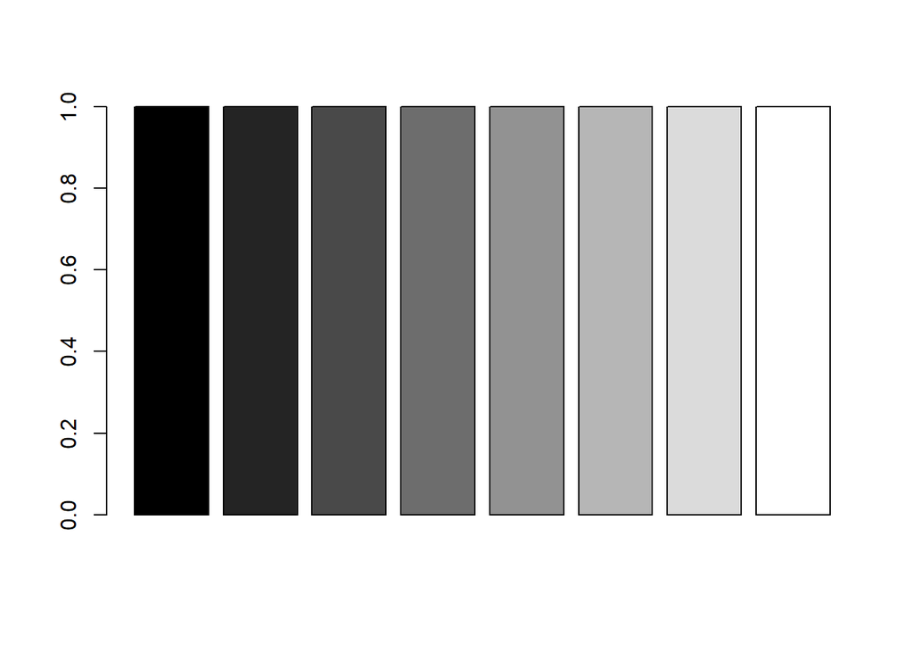

```r
barplot(rep(1, 8), col=1:8)
```

#### 09.2_3 colorRampPalette() 함수 이용하기

colorRampPalette() 함수는 주어진 색상 집합을 보간(interpolate)하여 새로운 색상 palette를 제공한다.  
colorRampPalette() 함수는 지정한 컬러를 이용하여 원하는 수의 컬러 스펙트럼을 제공해준다(해당 RGB 코드를 기준으로).  
색의 배열 순서를 바꾸고자 할 경우에는 rev() 함수가 유용하다.

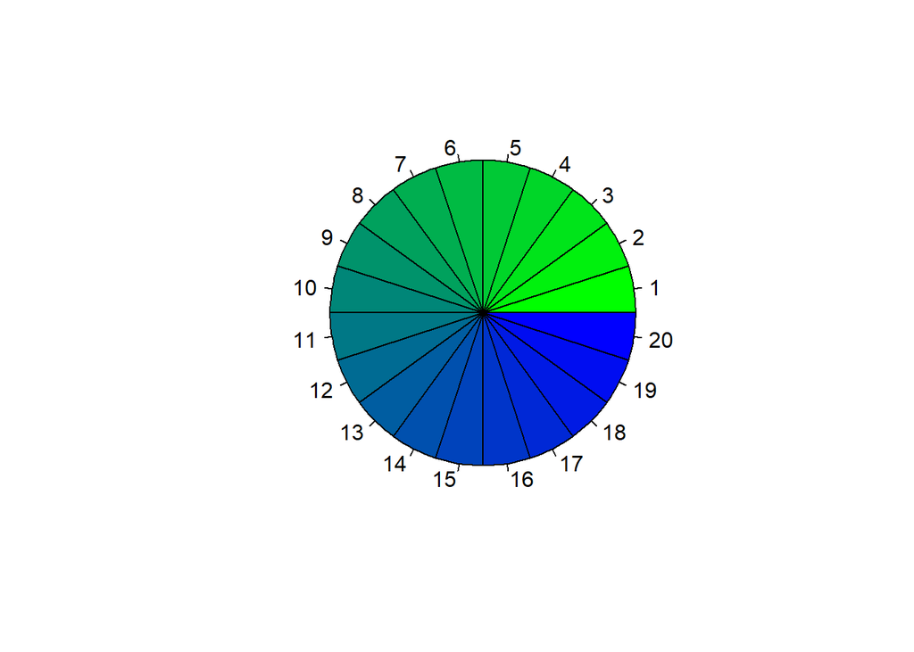

```r
b <- colorRampPalette(c("green", "blue"))(20)
pie(rep(1, 20), col=b)
```

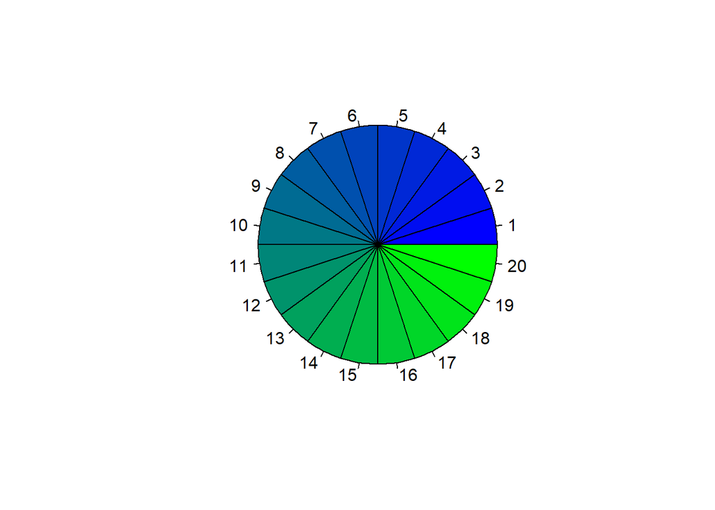

```r
pie(rep(1, 20), col=rev(b))
```

#### 09.2_4 brewer.pal{RColorBrewer} 함수 이용하기

```
- Sequential : 값이 작을수록 밝ㅇ느색, 클수록 어두운색 사용
- Diverging : 중간 값에 밝은색, 작거나 큰 값에 대비되는 어두운색 사용
- Qualitative : class 간에 시각적 차이를 최대로 하는 색상을 사용
```

##### 예제2

brewer.pal() 함수와 colorRampPalette() 함수의 적용 예는 다음과 같다.

```r
## Blues(sequential palette)에서 9개 색상을 이용하여 palette를 생성
library(RColorBrewer)
pal.1 <- brewer.pal(9, "Blues")
pal.1
```

```
## [1] "#F7FBFF" "#DEEBF7" "#C6DBEF" "#9ECAE1" "#6BAED6" "#4292C6" "#2171B5"
## [8] "#08519C" "#08306B"
```

```r
## Blues(sequential palette)에서 9개 색상을 이용하여 100개 색상의 palette를 생성
pal.2 <- colorRampPalette(brewer.pal(9, "Blues"))(100)
pal.2
```

```
##   [1] "#F7FBFF" "#F4F9FE" "#F2F8FD" "#F0F7FD" "#EEF5FC" "#ECF4FB" "#EAF3FB"
##   [8] "#E8F1FA" "#E6F0F9" "#E4EFF9" "#E2EEF8" "#E0ECF7" "#DEEBF7" "#DCEAF6"
##  [15] "#DAE8F5" "#D8E7F5" "#D6E6F4" "#D5E5F4" "#D3E3F3" "#D1E2F2" "#CFE1F2"
##  [22] "#CDDFF1" "#CBDEF0" "#C9DDF0" "#C7DBEF" "#C5DAEE" "#C1D9ED" "#BED7EC"
##  [29] "#BBD6EB" "#B8D5EA" "#B5D3E9" "#B1D2E7" "#AED1E6" "#ABCFE5" "#A8CEE4"
##  [36] "#A4CCE3" "#A1CBE2" "#9ECAE1" "#9AC8E0" "#96C5DF" "#92C3DE" "#8EC1DD"
##  [43] "#89BEDC" "#85BCDB" "#81BADA" "#7DB8DA" "#79B5D9" "#75B3D8" "#71B1D7"
##  [50] "#6DAFD6" "#69ACD5" "#66AAD4" "#62A8D2" "#5FA6D1" "#5CA3D0" "#58A1CE"
##  [57] "#559FCD" "#529DCC" "#4E9ACB" "#4B98C9" "#4896C8" "#4493C7" "#4191C5"
##  [64] "#3E8EC4" "#3C8CC3" "#3989C1" "#3686C0" "#3484BE" "#3181BD" "#2E7EBC"
##  [71] "#2C7CBA" "#2979B9" "#2776B8" "#2474B6" "#2171B5" "#1F6FB3" "#1D6CB1"
##  [78] "#1B69AF" "#1967AD" "#1764AB" "#1562A9" "#135FA7" "#115CA5" "#0F5AA3"
##  [85] "#0D57A1" "#0B559F" "#09529D" "#084F9A" "#084D96" "#084A92" "#08478E"
##  [92] "#08458A" "#084286" "#083F82" "#083D7E" "#083A7A" "#083776" "#083572"
##  [99] "#08326E" "#08306B"
```

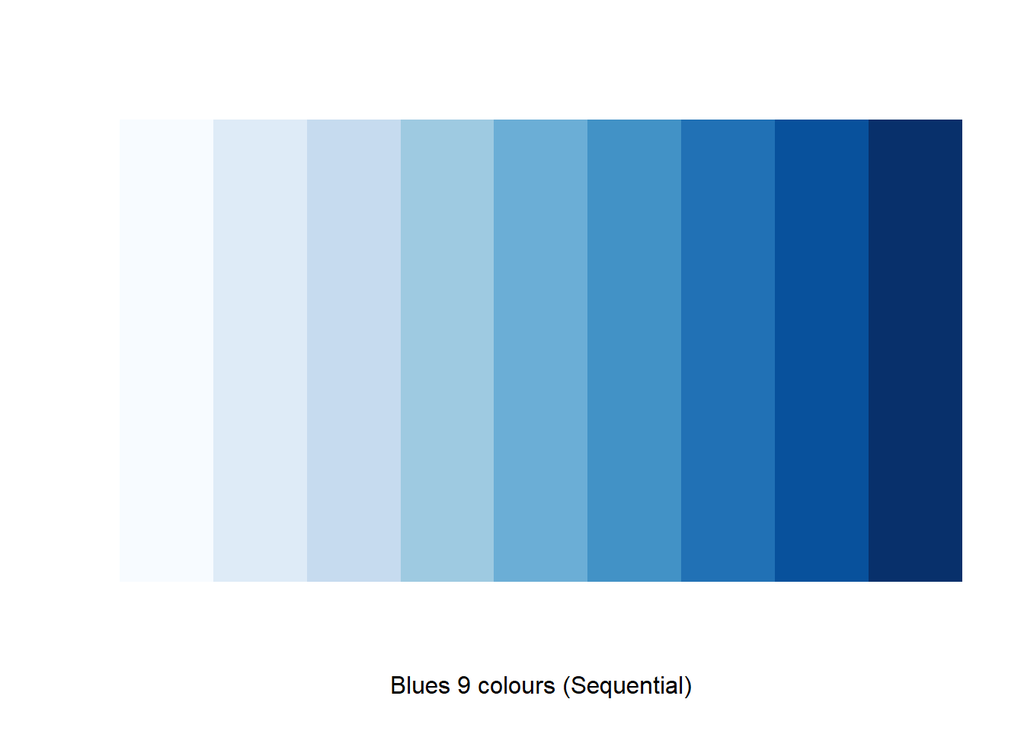

```r
## col=pal.1 옵션을 적용한 그림
image(1:9, 1, as.matrix(1:9), col=pal.1,
      xlab="Blues 9 colours (Sequential)", ylab="",
      xaxt="n", yaxt="n", bty="n")
```

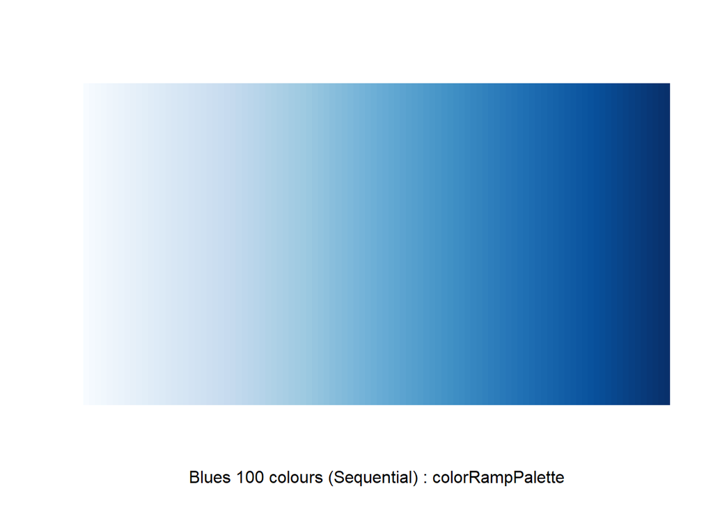

```r
## col=pal.2 옵션을 적용한 그림
image(1:100, 1, as.matrix(1:100), col=pal.2,
      xlab="Blues 100 colours (Sequential) : colorRampPalette", ylab="",
      xaxt="n", yaxt="n", bty="n")
```

앞 절에서 소개한 바와 같이, colorRampPalette() 함수는 다음과 같이 색상의 범위를 지정해주고, 지정된 두 색상 사이의 연속된 색상의 수를 몇 개로 할 것인지를 지정하여 사용할 수도 있다.

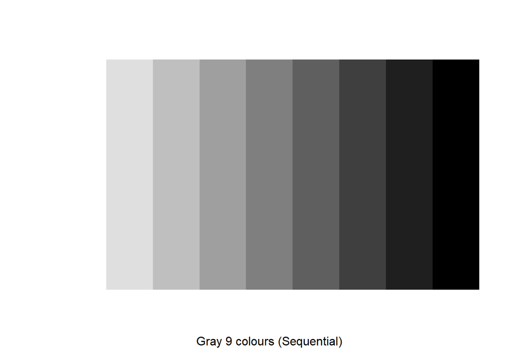

```r
pal.3 <- colorRampPalette(c("white", "black"))(9)
image(1:9, 1, as.matrix(1:9), col=pal.3,
      xlab="Gray 9 colours (Sequential)", ylab="",
      xaxt="n", yaxt="n", bty="n")
```

#### 09.2_5 rich.colors{gplot} 함수 이용하기

풍부한 색상 palette를 제공하는 함수로, 편리한 방법으로 n개의 색상 스펙트럼을 지정할 수 있다.  
이 함수는 palette로 지정된 색상을 등 간격으로 나눈 색상 스펙트럼을 제공한다.  
rich.colors() 함수의 palette= 옵션은 “temperature”(default)와 “blues”를 제공한다.  
“temperature”는 blue-green-yellow-red 색상을 포함하며, “blues”는 black-blue-white 색상을 포함한다.

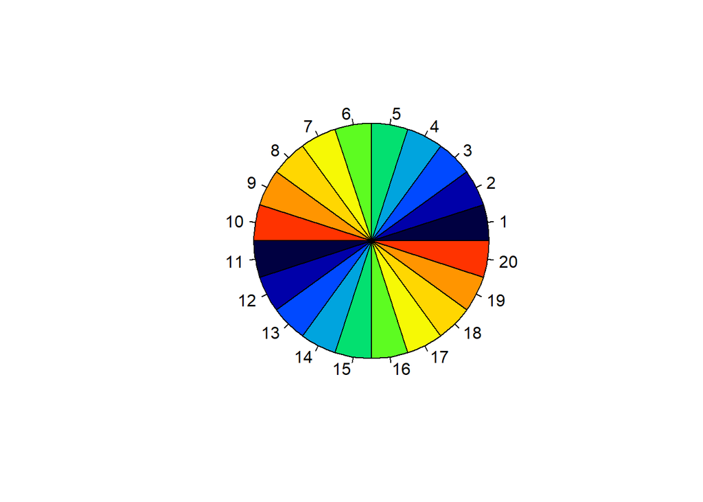

```r
library(gplots)
pie(rep(1, 20), col=rich.colors(palette="temperature", 10))
```

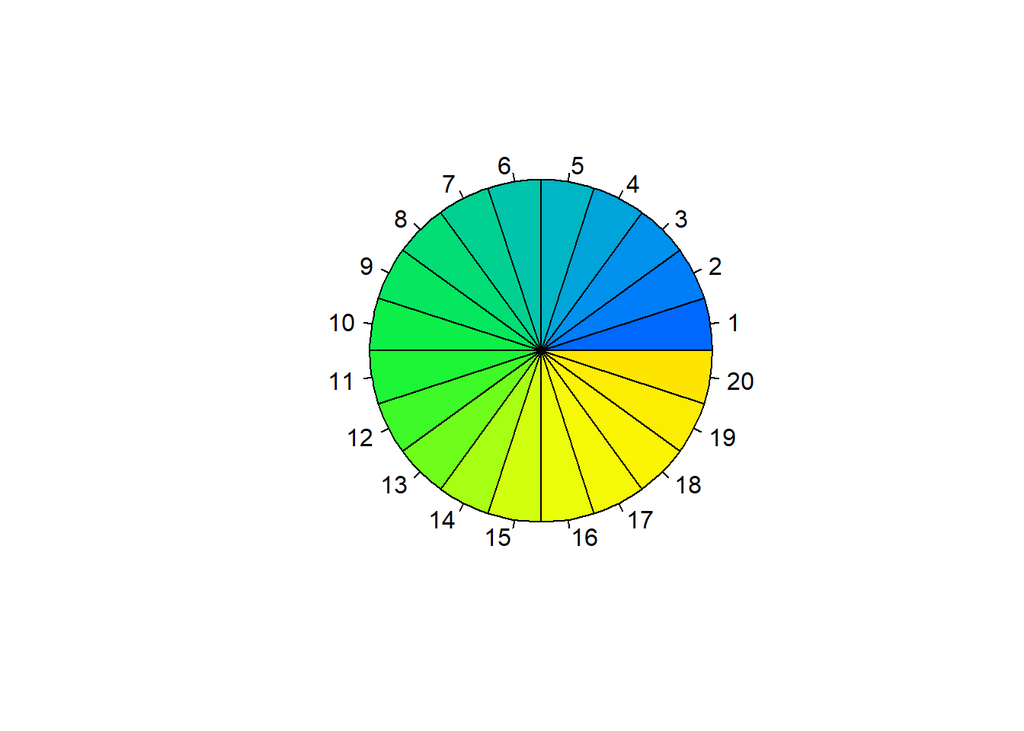

```r
pie(rep(1, 20), col=rich.colors(palette="temperature", 40)[11:30])
```

pie(rep(1, 20), col=rich.colors(palette=“temperature”, 10))는 temperature palette는 b-g-y-r 색상을 10개의 등간격으로 나눈 색상 스펙트럼을 제공한다.  
위 그림은 칸이 20개 이므로 재순환(recycle)이 적용되었다.  
pie(rep(1, 20), col=rich.colors(palette=“temperature”, 40)[11:30])는 40개로 나누어진 색상에서 11~30번째 색상을 선택한다.